# Analysing historical voting of the United Nations General Assembly

Utkarsh Sharma

16/09/2019

# Analysing historical voting of the United Nations General Assembly

The [dataset](https://dataverse.harvard.edu/api/access/datafile/:persistentId?persistentId=doi:10.7910/DVN/LEJUQZ/KKG7SW) contains the historical voting data from the General Assembly of the United Nations. This is a dataset of roll-call votes in the UN General Assembly 1946-2018. In the General Assembly, every member nation gets a vote, which makes the voting history a great resource to study international relations.

The raw data was sourced from the Harvard Dataverse.

*Citation: Voeten, Erik; Strezhnev, Anton; Bailey, Michael, 2009, “UN-73new.RData”, United Nations General Assembly Voting Data, https://doi.org/10.7910/DVN/LEJUQZ/KKG7SW, Harvard Dataverse, V21*

```r
#Importing and installing required libraries
library(dplyr)
library(ggplot2)

# Loading dataset
load("~/Desktop/Analysing historical voting of the United Nations General Assembly/Dataset/UN-73new.RData")
```

Checking out the first six rows of the dataset.

```r
  head(completeVotes)
```

```
## # A tibble: 6 x 34
## # Groups:   rcid, ccode, Countryname [6]
##    rcid ccode member  vote Country Countryname year  session abstain   yes
##   <dbl> <dbl>  <dbl> <dbl> <chr>   <chr>       <chr>   <dbl>   <dbl> <dbl>
## 1     3     2      1     1 USA     United Sta… 1946        1       4    29
## 2     3    20      1     3 CAN     Canada      1946        1       4    29
## 3     3    31     NA     9 BHS     Bahamas     1946        1       4    29
## 4     3    40      1     1 CUB     Cuba        1946        1       4    29
## 5     3    41      1     1 HTI     Haiti       1946        1       4    29
## 6     3    42      1     1 DOM     Dominican … 1946        1       4    29
## # … with 24 more variables: no <dbl>, importantvote <int>, date <date>,
## #   unres <chr>, amend <int>, para <int>, short <chr>, descr <chr>,
## #   me <dbl>, nu <dbl>, di <dbl>, hr <dbl>, co <dbl>, ec <dbl>,
## #   Meeting <chr>, Results <chr>, Details <fct>, Notes <fct>,
## #   Votes.Counted <int>, motion <int>, Extra <dbl>,
## #   Related.Documents <chr>, ident <dbl>, resid <chr>
```

The vote column in the dataset has a number that represents that country’s vote:

1 = Yes, 2 = Abstain, 3 = No, 8 = Not present, 9 = Not a member

To study the international relationships between countries, we filter out the result with voting results ‘Not present’ and ‘Not a member’.

```r
  filteredVotes <- completeVotes %>%
                  filter(vote %in% c("1", "2", "3"))
```

## Year-over-year consensus

To find the year-by-year overall trend of voting against or for the international consensus, we plot the year-by-year percentage of “Yes” votes.

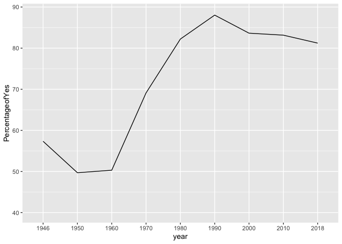

```r
  year_by_yearYes <- filteredVotes %>%
                    group_by(year) %>%
                    summarize(PercentageofYes = mean(vote == 1) * 100)

  years <- c("1946", "1950", "1960", "1970", "1980", "1990", "2000", "2010", "2018")

  ggplot(year_by_yearYes, aes(year, PercentageofYes, group = 1)) + geom_line() + xlim(years)
```

Here, it can be easily seen that the overall consensus has greatly improved since 1960.

## Country consensus

If a country tends to votes “Yes” on most occassions, it can be inferred that it tends to agree with the international consensus, while if it votes “No” on most occassions, it can be assumed that it tends to go against the consensus.

```r
  byCountryYes <- filteredVotes %>%
                  group_by(Countryname) %>%
                  summarize(Votes = n(), PercentageofYes = mean(vote == 1) * 100)

  head(byCountryYes %>% arrange(PercentageofYes))
```

```
## # A tibble: 6 x 3
##   Countryname                                         Votes PercentageofYes
##   <chr>                                               <int>           <dbl>
## 1 Zanzibar                                                2             0
## 2 United States of America                             6065            29.5
## 3 Israel                                               5593            34.2
## 4 Federal Republic of Germany                          2067            39.6
## 5 Palau                                                1293            43.1
## 6 United Kingdom of Great Britain and Northern Irela…  6050            44.6
```

It can be seen that the country Zanzibar only has 2 votes casted in the General Assembly. To get a clearer picture, we filter out country with low number of votes.

```r
  head(byCountryYes %>% filter(Votes > 200) %>% arrange(desc(PercentageofYes)))
```

```
## # A tibble: 6 x 3
##   Countryname           Votes PercentageofYes
##   <chr>                 <int>           <dbl>
## 1 Seychelles             2030            97.6
## 2 Sao Tome and Principe  2620            96.2
## 3 Cabo Verde             3854            95.5
## 4 Timor-Leste            1302            95.1
## 5 Guinea Bissau          3530            95.0
## 6 Djibouti               3983            93.9
```

### Country consensus over the years

To study trends of voting within specific countries rather than the overall trend we summarize the data by both year and country.

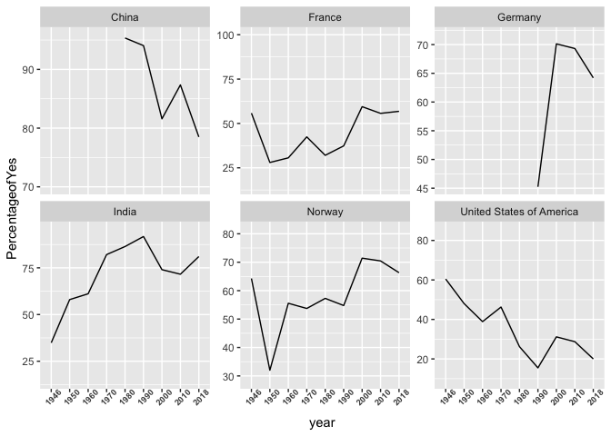

```r
  summarizedVotes <- filteredVotes %>% group_by(year, Countryname) %>% summarize(Votes = n(), PercentageofYes = mean(vote == 1) * 100)

  Countries <- c("United States of America", "Norway", "India","Germany", "France", "China")

  filteredCountry <- summarizedVotes %>% filter(Countryname %in% Countries)

  ggplot(filteredCountry, aes(year, PercentageofYes, group = 1)) + geom_line() + xlim(years) + facet_wrap(~Countryname, scales = "free_y") + theme(axis.text.x = element_text(face="bold", size=07, angle=45))
```